# Bayesian GLMM Part1

Author

Murray Logan

Published

09/09/2025

# 1 Preparations

Load the necessary libraries

```r
library(tidyverse) # for data wrangling etc
library(rstanarm) # for fitting models in STAN
library(cmdstanr) # for cmdstan
library(brms) # for fitting models in STAN
library(standist) # for exploring distributions
library(HDInterval) # for HPD intervals
library(posterior) # for posterior draws
library(coda) # for diagnostics
library(bayesplot) # for diagnostics
library(ggmcmc) # for diagnostics
library(rstan) # for interfacing with STAN
library(DHARMa) # for residual diagnostics
library(emmeans) # for marginal means etc
library(broom) # for tidying outputs
library(broom.mixed) # for tidying MCMC outputs
library(tidybayes) # for more tidying outputs
library(ggeffects) # for partial plots
library(patchwork) # for multiple figures
library(bayestestR) # for ROPE
library(see) # for some plots
library(ggridges) # for ridge plots
library(easystats) # framework for stats, modelling and visualisation
library(modelsummary)
source("helperFunctions.R")
```

# 2 Scenario

A plant pathologist wanted to examine the effects of two different strengths of tobacco virus on the number of lesions on tobacco leaves. She knew from pilot studies that leaves were inherently very variable in response to the virus. In an attempt to account for this leaf to leaf variability, both treatments were applied to each leaf. Eight individual leaves were divided in half, with half of each leaf inoculated with weak strength virus and the other half inoculated with strong virus. So the leaves were blocks and each treatment was represented once in each block. A completely randomised design would have had 16 leaves, with 8 whole leaves randomly allocated to each treatment.

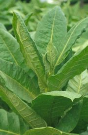

**Figure** 1: Tobacco plant

**Table** 1: Format of tobacco.csv data files

| LEAF | TREAT | NUMBER |
| --- | --- | --- |
| 1 | Strong | 35.898 |
| 1 | Week | 25.02 |
| 2 | Strong | 34.118 |
| 2 | Week | 23.167 |
| 3 | Strong | 35.702 |
| 3 | Week | 24.122 |
| ... | ... | ... |

**Table** 2: Description of the variables in the tobacco data file

| **LEAF** | The blocking factor - Factor B |
| --- | --- |
| **TREAT** | Categorical representation of the strength of the tobacco virus - main factor of interest Factor A |
| **NUMBER** | Number of lesions on that part of the tobacco leaf - response variable |

# 3 Read in the data

```r
tobacco <- read_csv("../data/tobacco.csv", trim_ws = TRUE)
```

**glimpse**

```r
glimpse(tobacco)
```

```
Rows: 16
Columns: 3
$ LEAF      <chr> "L1", "L1", "L2", "L2", "L3", "L3", "L4", "L4", "L5", "L5", …
$ TREATMENT <chr> "Strong", "Weak", "Strong", "Weak", "Strong", "Weak", "Stron…
$ NUMBER    <dbl> 35.89776, 25.01984, 34.11786, 23.16740, 35.70215, 24.12191, …
```

**head**

```r
## Explore the first 6 rows of the data
head(tobacco)
```

```
# A tibble: 6 × 3
  LEAF  TREATMENT NUMBER
  <chr> <chr>      <dbl>
1 L1    Strong      35.9
2 L1    Weak        25.0
3 L2    Strong      34.1
4 L2    Weak        23.2
5 L3    Strong      35.7
6 L3    Weak        24.1
```

**str**

```r
str(tobacco)
```

```
spc_tbl_ [16 × 3] (S3: spec_tbl_df/tbl_df/tbl/data.frame)
 $ LEAF     : chr [1:16] "L1" "L1" "L2" "L2" ...
 $ TREATMENT: chr [1:16] "Strong" "Weak" "Strong" "Weak" ...
 $ NUMBER   : num [1:16] 35.9 25 34.1 23.2 35.7 ...
 - attr(*, "spec")=
  .. cols(
  ..   LEAF = col_character(),
  ..   TREATMENT = col_character(),
  ..   NUMBER = col_double()
  .. )
 - attr(*, "problems")=<externalptr>
```

**Easystats (datawizard)**

```r
tobacco |> datawizard::data_codebook()
```

```
tobacco (16 rows and 3 variables, 3 shown)

ID | Name      | Type      | Missings |         Values |         N
---+-----------+-----------+----------+----------------+----------
1  | LEAF      | character | 0 (0.0%) |             L1 | 2 (12.5%)
   |           |           |          |             L2 | 2 (12.5%)
   |           |           |          |             L3 | 2 (12.5%)
   |           |           |          |             L4 | 2 (12.5%)
   |           |           |          |             L5 | 2 (12.5%)
   |           |           |          |             L6 | 2 (12.5%)
   |           |           |          |             L7 | 2 (12.5%)
   |           |           |          |             L8 | 2 (12.5%)
---+-----------+-----------+----------+----------------+----------
2  | TREATMENT | character | 0 (0.0%) |         Strong | 8 (50.0%)
   |           |           |          |           Weak | 8 (50.0%)
---+-----------+-----------+----------+----------------+----------
3  | NUMBER    | numeric   | 0 (0.0%) | [20.57, 44.72] |        16
------------------------------------------------------------------
```

**Skim (modelsummary)**

Unique

Missing Pct.

Mean

SD

Min

Median

Max

Histogram

NUMBER

16

0

31.0

6.5

20.6

33.1

44.7

[figure not shown]

N

%

LEAF

L1

2

12.5

L2

2

12.5

L3

2

12.5

L4

2

12.5

L5

2

12.5

L6

2

12.5

L7

2

12.5

L8

2

12.5

TREATMENT

Strong

8

50.0

Weak

8

50.0

```r
tobacco |> modelsummary::datasummary_skim()
```

TREATMENT

Unique

Missing Pct.

Mean

SD

Min

Median

Max

Histogram

NUMBER

Strong

8

0

34.9

5.1

26.2

34.9

44.7

[figure not shown]

Weak

8

0

27.1

5.5

20.6

25.1

36.0

[figure not shown]

N

%

LEAF

L1

2

12.5

L2

2

12.5

L3

2

12.5

L4

2

12.5

L5

2

12.5

L6

2

12.5

L7

2

12.5

L8

2

12.5

TREATMENT

Strong

8

50.0

Weak

8

50.0

```r
tobacco |> modelsummary::datasummary_skim(by = "TREATMENT")
```

# 4 Exploratory data analysis

**Boxplots**

To explore the assumptions of homogeneity of variance and normality, a boxplot of each Treatment level is appropriate.

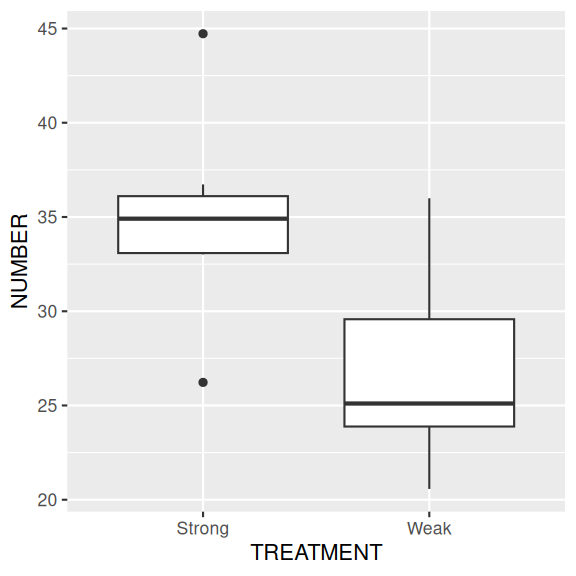

```r
ggplot(tobacco, aes(y = NUMBER, x = TREATMENT)) +
  geom_boxplot()
```

**Conclusions:**

- both normality and homogeneity of variance seem satisfied

**Line plots**

It can also be useful to get a sense of the consistency across blocks (LEAF). That is, do all Leaves have a similar baseline level of lesion susceptibility and do they respond similarly to the treatment.

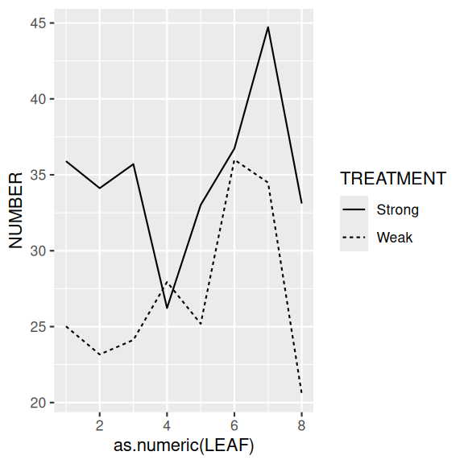

```r
ggplot(tobacco, aes(y = NUMBER, x = as.numeric(LEAF))) +
  geom_line(aes(linetype = TREATMENT))
```

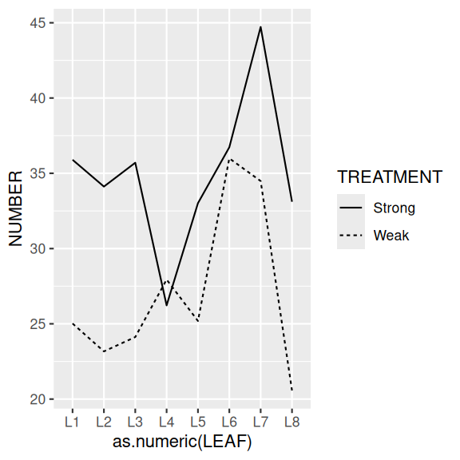

```r
## If we want to retain the original LEAF labels
ggplot(tobacco, aes(y = NUMBER, x = as.numeric(LEAF))) +
  geom_blank(aes(x = LEAF)) +
  geom_line(aes(linetype = TREATMENT))
```

**Conclusions:**

- it is clear that some leaves are more susceptible to lesions (e.g. Leaf 7) than other leaves (e.g. Leaf 4)
- most leaves (other than Leaf 4 and 6) have a similar response to the Treatments - that is most have higher number of lesions from the Strong Treatment than the Weak Treatment.

**Paired plots**

Given that there are only two levels of Treatment (Strong and Weak), it might be easier to visualise the differences in baselines and effect consistency by plotting as:

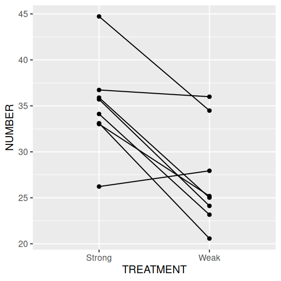

```r
ggplot(tobacco, aes(y = NUMBER, x = TREATMENT, group = LEAF)) +
  geom_point() +
  geom_line(aes(x = as.numeric(TREATMENT)))
```

**Conclusions:**

- this figure reiterates the points made earlier about the varying baselines and effect consistency.

The above figure also serves as a good way to visualise certain aspects of mixed effects models. When we fit a mixed effects model that includes a random blocking effect (in this case LEAF), we are indicating that we are allowing there to be a different intercept for each block (LEAF). In the current case, the intercept will represent the first Treatment level (Strong). So the random effect is specifying that the intercept can vary from Leaf to Leaf.

We can think of the model as having two tiers (a hierarchy), where the tiers of the hierarchy represent progressively smaller (typically) spatial scales. In the current example, the largest spatial units are the leaves (blocking factor). Within the leaves, there are the two Treatments (Strong and Weak) and within the Treatments are the individual observations.

From a frequentist perspective, this model might be referred to as a mixed effects model in which the `TREATMENT` is a ‘fixed’ effect and the `LEAF` is a ‘random’ effect. Such terminology is inconsistent in a Bayesian context since all parameters are ‘random’. Instead, these would be referred to as *population-level* and *group-level* effects respectively. Group-level effects are so called because they are effects that differ within each group (e.g. level of a blocking factor), whereas population effects are those that have been pooled across all groups.

Random intercepts model formula:
$$\begin{align}
y_{i,j} &\sim{} \mathcal{N}(\mu_{i,j}, \sigma^2)\\
\mu_{i,j} &=\beta_0 + \bf{Z_j}\boldsymbol{\gamma_j} + \bf{X_i}\boldsymbol{\beta} \\
\beta_0 &\sim{} \mathcal{N}(35, 3)\\
\beta_1 &\sim{} \mathcal{N}(0, 10)\\
\boldsymbol{\gamma_j} &\sim{} \mathcal{N}(0, \sigma^2_l)\\
\sigma^2_l &\sim{} t(3, 0, 5)\\
\sigma^2 &\sim{} t(3, 0, 5)\
\end{align}$$

Random intercept/slope model formula:
$$\begin{align}
y_{i,j} &\sim{} \mathcal{N}(\mu_{i,j}, \sigma^2)\\
\mu_{i,j} &=\beta_0 + \bf{Z_j}\boldsymbol{\gamma_j} + \bf{X_i}\boldsymbol{\beta} \\
\beta_0 &\sim{} \mathcal{N}(35, 3)\\
\beta_1 &\sim{} \mathcal{N}(0, 10)\\
\boldsymbol{\gamma_j} &\sim{} \mathcal{N}(0, \boldsymbol{\Sigma})\\
\boldsymbol{\Sigma} &= \boldsymbol{D}({\sigma_l})\boldsymbol{\Omega}\boldsymbol{D}({\sigma_l^2})\\
\boldsymbol{\Omega} &\sim{} LKJ(\zeta)\\
\sigma_l^2 &\sim{} \mathcal{t}(3,0,5)\\
\sigma^2 &\sim{} \mathcal{t}(3, 0, 5)\
\end{align}$$

where:

$$\begin{align}
\gamma &\sim{} N(0,\Sigma)\\
\Sigma &-> \Omega, \tau\\
\end{align}$$

where $\Sigma$ is a covariance matrix.

It turns out that it is difficult to apply a prior on a covariance matrix, so instead, we decompose the covariance matrix into a correlation matrix and variance.

https://jrnold.github.io/bayesian_notes/appendix.html - Section 20.15.3 Covariance-Correlation Matrix Decomposition

- Covariance matrix can be decomposed into a correlation matrix and a vector of variances
- The variances can be further decomposed into the product of a simplex vector (which is a probability vector, non-negative and sums to 1) and the trace (product of the order of the matrix and the scale of the scale parameter, also the sum of its diagonal elements) of a matrix. Each element of the simplex vector represents the proportion of the trace that is attributable to the corresponding variable.
- A prior on all the above is a decov (decomposition of covariance) function
- The prior on the correlation matrix is called LKJ
- density is proportional to the determinant of the correlation matrix raised to the power of the positive regularization paramter minus one.
- The prior on the simplex vector is a symmetric Dirichlet prior which has a single (positive) concentration parameter (default of 1 implying the prior is jointly uniform over the same of simplex vectors of that size) A symmetric Dirichlet prior is used for the simplex vector. The Dirichlet prior has a single (positive) concentration parameter
- The positive scale paramter has a gamma prior (with default shape and scale of 1 - implying a unit-exponential distribution)
- alternatively, the lkj prior can be used for covariance.
- as with decov, it decomposes into correlation and variances, however the variances are not further decomosed into a simplex vector and trace.
- instead the standard deviations (variance squared) for each of the group specific paramters are given half student-t distribution with scale and df paramters specified through the scale (default 10) and df (default 1) arguments of the lkj function.
- the lkj prior is similar, yet faster than decov

# 5 Fit the model

**rstanarm**

**Using default priors**

In `rstanarm`, the default priors are designed to be weakly informative. They are chosen to provide moderate regularlization (to help prevent overfitting) and help stabalise the computations.

```r
tobacco_rstanarm <- stan_glmer(NUMBER ~ (1 | LEAF) + TREATMENT,
  data = tobacco,
  family = gaussian(),
  iter = 5000,
  warmup = 2000,
  chains = 3,
  thin = 5,
  refresh = 0
)
```

```r
tobacco_rstanarm |> prior_summary()
```

```
Priors for model 'tobacco_rstanarm'
------
Intercept (after predictors centered)
  Specified prior:
    ~ normal(location = 31, scale = 2.5)
  Adjusted prior:
    ~ normal(location = 31, scale = 16)

Coefficients
  Specified prior:
    ~ normal(location = 0, scale = 2.5)
  Adjusted prior:
    ~ normal(location = 0, scale = 32)

Auxiliary (sigma)
  Specified prior:
    ~ exponential(rate = 1)
  Adjusted prior:
    ~ exponential(rate = 0.15)

Covariance
 ~ decov(reg. = 1, conc. = 1, shape = 1, scale = 1)
------
See help('prior_summary.stanreg') for more details
```

This tells us:

- for the intercept (when the family is Gaussian), a normal prior with a mean of 31 and a standard deviation of 16 is used. The 2.5 is used for scaling all parameter standard deviations. The value of 31 is based on the mean of the response (`mean(tobacco$NUMBER)`) and the scaled standard deviation of 16 is based on multiplying the scaling factor by the standard deviation of the response.

```r
2.5 * sd(tobacco$NUMBER)
```

```
[1] 16.35115
```

- for the coefficients (in this case, just the difference between strong and weak innoculation), the default prior is a normal prior centered around 0 with a standard deviation of 2.5. This is then adjusted for the scale of the data by multiplying the 2.5 by the ratio of the standard deviation of the response by the stanard devation of the numerical dummy variables for the predictor (then rounded).

```r
2.5 * sd(tobacco$NUMBER) / apply(model.matrix(~TREATMENT, tobacco), 2, sd)
```

```
  (Intercept) TREATMENTWeak
          Inf      31.66386
```

- the auxillary prior represents whatever additional prior is required for the nominated model. In the case of a Gaussian model, this will be $\sigma$, for negative binomial, it will be the reciprocal of dispersion, for gamma, it will be shape, etc . By default in `rstanarm`, this is a exponential with a rate of 1 which is then adjusted by devision with the standard deviation of the response.

```r
1 / sd(tobacco$NUMBER)
```

```
[1] 0.1528945
```

**Assessing priors**

Lets now run with priors only so that we can explore the range of values they allow in the posteriors.

```r
tobacco_rstanarm1 <- update(tobacco_rstanarm, prior_PD = TRUE)
```

```
Note: uncertainty of error terms are not taken into account. Consider
  setting `interval` to "prediction". This will call `posterior_predict()`
  instead of `posterior_epred()`.
```

```
Data points may overlap. Use the `jitter` argument to add some amount of
  random variation to the location of data points and avoid overplotting.
```

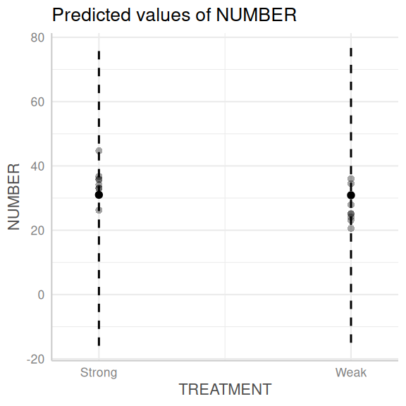

```r
ggpredict(tobacco_rstanarm1) |> plot(show_data = TRUE)
```

**Conclusions:**

- we see that the range of predictions is faily wide and the predicted means could range from a small negative number to a relatively large positive number.

**Defining priors**

The following link provides some guidance about defining priors. [https://github.com/stan-dev/stan/wiki/Prior-Choice-Recommendations]

When defining our own priors, we typically do not want them to be scaled.

If we wanted to define our own priors that were less vague, yet still not likely to bias the outcomes, we could try the following priors (mainly plucket out of thin air):

- $\beta_0$: normal centered at 35 with a standard deviation of 7
  - mean of 33: since `median(tobacco$NUMBER)`
  - sd of 7: since `mad(tobacco$NUMBER)`
- $\beta_1$: normal centred at 0 with a standard deviation of 13
  - sd of 13: since `sd(tobacco$NUMBER) / apply(model.matrix(~TREATMENT, tobacco), 2, sd)`
- $\sigma$: exponential with rate of 0.15
  - since `1 / sd(tobacco$NUMBER)`
- $\Sigma$: decov with:
  - regularization: the exponent for a LKJ prior on the correlation matrix. A value of 1 (default) implies a joint uniform prior
  - concentration: the concentration parameter for a symmetric Dirichlet distribution. A value of 1 (default) implies a joint uniform distribution
  - shape and scale: the shape and scale parameters for a gamma prior on the scale and scale parameters of the decov prior. A value of 1 for both (default) simplifies the gamma prior to a unit-exponential distribution.

I will also overlay the raw data for comparison.

```r
tobacco_rstanarm2 <- stan_glmer(NUMBER ~ (1 | LEAF) + TREATMENT,
  data = tobacco,
  family = gaussian(),
  prior_intercept = normal(35, 7, autoscale = FALSE),
  prior = normal(0, 13, autoscale = FALSE),
  prior_aux = rstanarm::exponential(0.15, autoscale = FALSE),
  prior_covariance = decov(1, 1, 1, 1),
  prior_PD = TRUE,
  iter = 5000,
  warmup = 1000,
  chains = 3,
  thin = 5,
  refresh = 0
)
```

```
Note: uncertainty of error terms are not taken into account. Consider
  setting `interval` to "prediction". This will call `posterior_predict()`
  instead of `posterior_epred()`.
```

```
Data points may overlap. Use the `jitter` argument to add some amount of
  random variation to the location of data points and avoid overplotting.
```

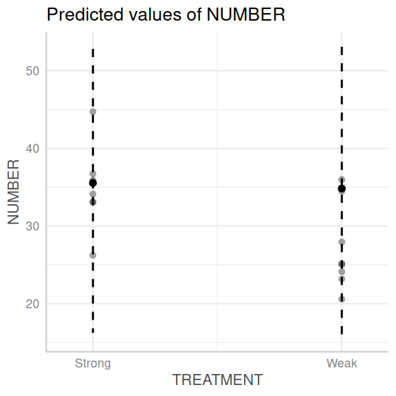

```r
tobacco_rstanarm2 |>
  ggpredict() |>
  plot(show_data = TRUE)
```

Now lets refit, conditioning on the data.

```r
tobacco_rstanarm3 <- update(tobacco_rstanarm2, prior_PD = FALSE)
```

**Plotting prior and posterior**

```
Drawing from prior...
```

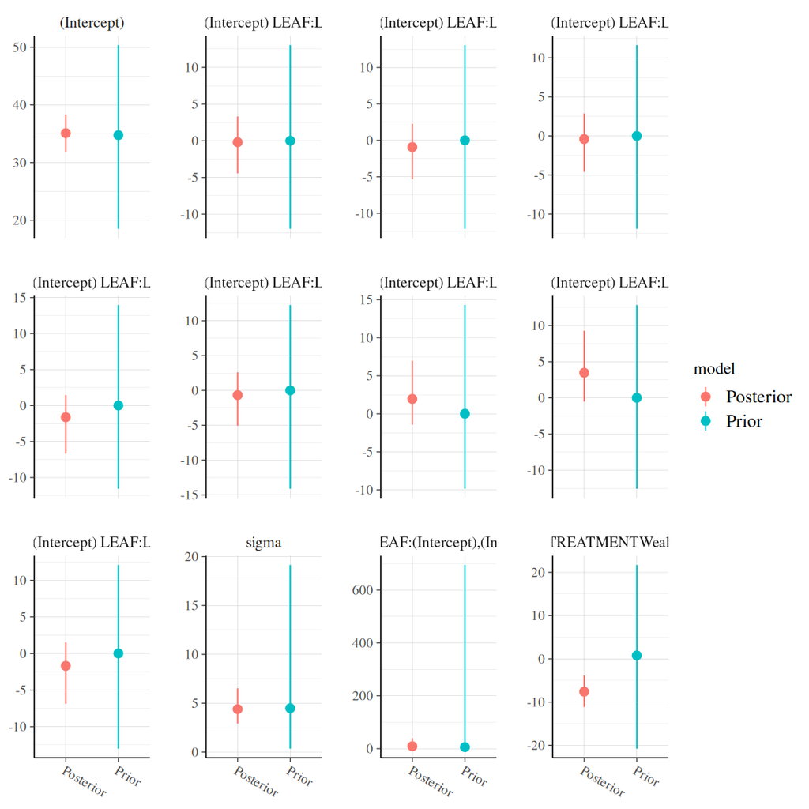

```r
posterior_vs_prior(tobacco_rstanarm3,
  color_by = "vs", group_by = TRUE,
  facet_args = list(scales = "free_y")
)
```

**Conclusions:**

- in each case, the prior is substantially wider than the posterior, suggesting that the posterior is not biased towards the prior.

```
Data points may overlap. Use the `jitter` argument to add some amount of
  random variation to the location of data points and avoid overplotting.
```

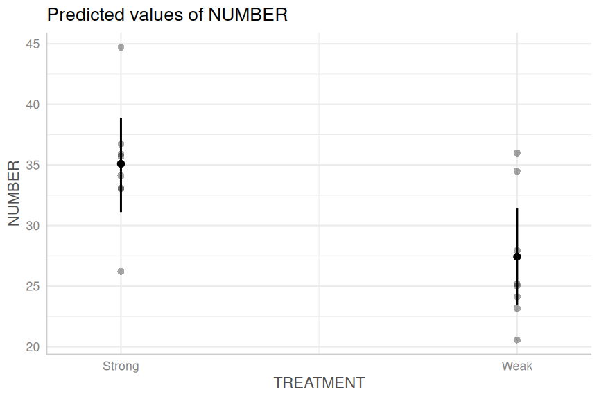

```r
ggemmeans(tobacco_rstanarm3, ~TREATMENT) |> plot(show_data = TRUE)
```

```
Note: uncertainty of error terms are not taken into account. Consider
  setting `interval` to "prediction". This will call `posterior_predict()`
  instead of `posterior_epred()`.
Data points may overlap. Use the `jitter` argument to add some amount of
  random variation to the location of data points and avoid overplotting.
```

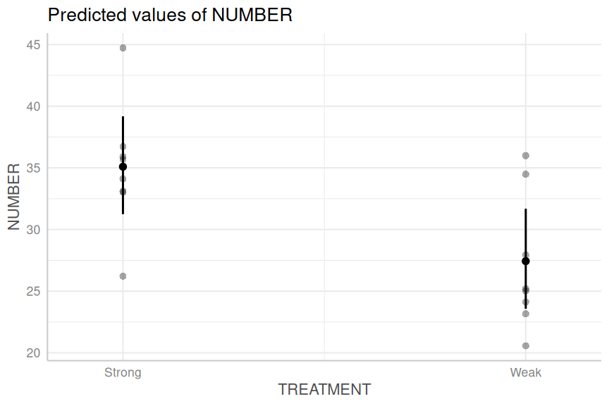

```r
ggpredict(tobacco_rstanarm3, ~TREATMENT) |> plot(show_data = TRUE)
```

**brms**

**Using default priors**

In `brms`, the default priors are designed to be weakly informative. They are chosen to provide moderate regularlization (to help prevent overfitting) and help stabalise the computations.

Unlike `rstanarm`, `brms` models must be compiled before they start sampling. For most models, the compilation of the stan code takes around 45 seconds.

```r
tobacco_form <- bf(NUMBER ~ (1|LEAF) + TREATMENT,
                   family = gaussian()
                   )
options(width=100)
tobacco_form |> get_prior(data=tobacco)
```

```
                   prior     class          coef group resp dpar nlpar lb ub       source
                  (flat)         b                                                default
                  (flat)         b TREATMENTWeak                             (vectorized)
 student_t(3, 33.1, 6.5) Intercept                                                default
    student_t(3, 0, 6.5)        sd                                      0         default
    student_t(3, 0, 6.5)        sd                LEAF                  0    (vectorized)
    student_t(3, 0, 6.5)        sd     Intercept  LEAF                  0    (vectorized)
    student_t(3, 0, 6.5)     sigma                                      0         default
```

```r
## tobacco_brm <- brm(tobacco_form,
##                   iter = 5000,
##                   warmup = 1000,
##                   chains = 3,
##                   thin = 5,
##                   refresh = 0)
```

**Defining priors**

The following link provides some guidance about defining priors. [https://github.com/stan-dev/stan/wiki/Prior-Choice-Recommendations]

When defining our own priors, we typically do not want them to be scaled.

If we wanted to define our own priors that were less vague, yet still not likely to bias the outcomes, we could try the following priors (mainly plucket out of thin air):

Note, for hierarchical models, the model will tend to want to have a large $sigma$ in order to fit the data better. It is a good idea to **regularise** this tendency by applying a prior that has most mass around zero. Suitable candidates include:

- half-t: as the degrees of freedom approach infinity, this will approach a half-normal
- half-cauchy: this is essentially a half-t with 1 degree of freedom
- exponential

I will also overlay the raw data for comparison.

```r
tobacco |>
  group_by(TREATMENT) |>
  summarise(
    median(NUMBER),
    mad(NUMBER)
  )
```

```
# A tibble: 2 × 3
  TREATMENT `median(NUMBER)` `mad(NUMBER)`
  <fct>                <dbl>         <dbl>
1 Strong                34.9          2.68
2 Weak                  25.1          3.54
```

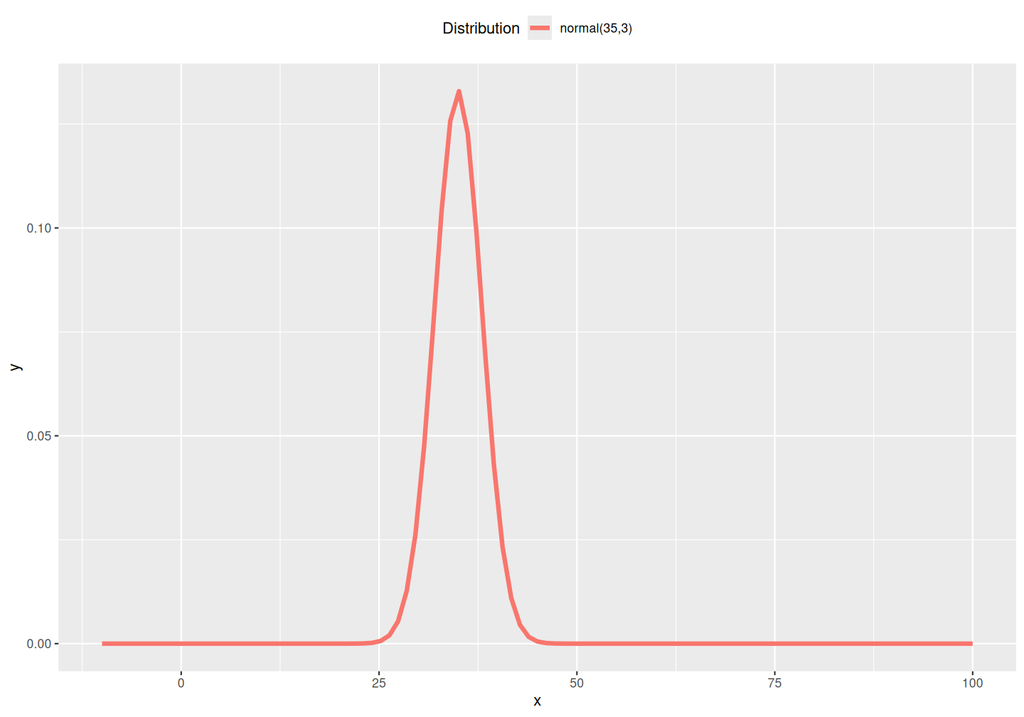

```r
standist::visualize("normal(35,3)", xlim = c(-10, 100))
```

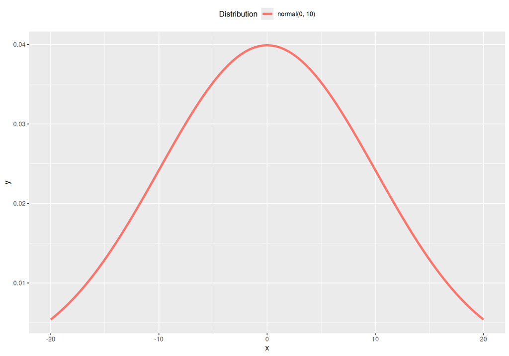

```r
standist::visualize("normal(0, 10)", xlim = c(-20, 20))
```

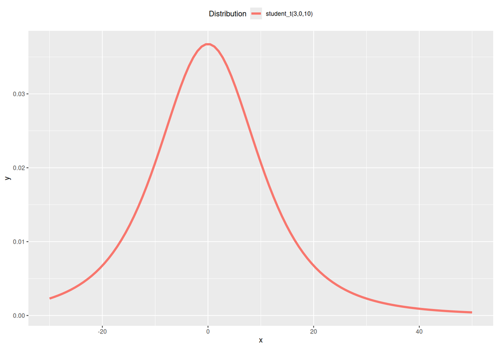

```r
standist::visualize(
  "student_t(3,0,10)",
  xlim = c(-30, 50)
)
```

```r
priors <- prior(normal(35, 3), class = "Intercept") +
  prior(normal(0, 10), class = "b") +
  prior(student_t(3, 0, 5), class = "sigma") +
  prior(student_t(3, 0, 5), class = "sd")
tobacco_form <- bf(NUMBER ~ (1 | LEAF) + TREATMENT,
  family = gaussian()
)
tobacco_brm2 <- brm(tobacco_form,
  data = tobacco,
  prior = priors,
  sample_prior = "only",
  iter = 5000,
  warmup = 2500,
  chains = 3, cores = 3,
  thin = 5,
  refresh = 0,
  backend = "rstan"
)
```

Note in the above model, the output may have included a warning message alerting us the presence of **divergent transitions**. Divergent transitions are an indication that the sampler has encountered poor sampling conditions - the more divergent transitions, the more severe the issue.

Typically, divergent transitions are the result of either:

- a miss-specified model
- priors that permit the sampler to drift into unsupported areas
- complex posterior “features” (with high degrees of curvature) for which the sampler was inadequately tuned during the warmup phase

One useful way to diagnose the cause of divergent transitions is to explore a parallel coordinates plot. Each parameter is on the x-axis and each line represents a single MCMC draw. Divergent transitions will be highlighted in red (by default). If lines pinch together at a particular parameter, then it points to that dimension as the cause of divergent transitions.

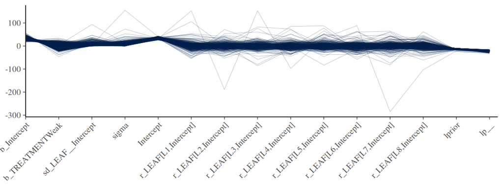

```r
tobacco_np <- nuts_params(tobacco_brm2)
tobacco_mcmc <- as.array(tobacco_brm2)
mcmc_parcoord(x = tobacco_mcmc, np = tobacco_np) +
  theme(axis.text.x = element_text(angle = 45, hjust = 1))
```

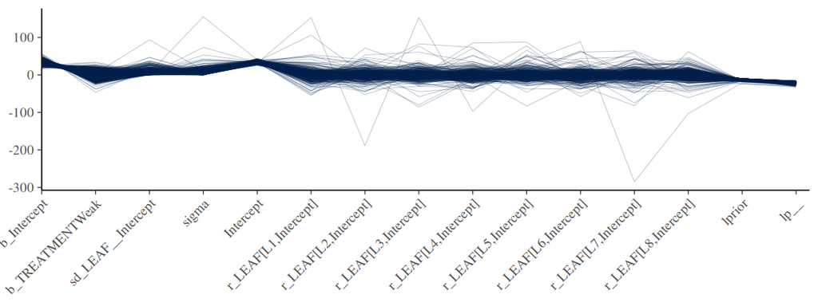

```r
tobacco_brm2 |> mcmc_parcoord(np = tobacco_np) +
  theme(axis.text.x = element_text(angle = 45, hjust = 1))
```

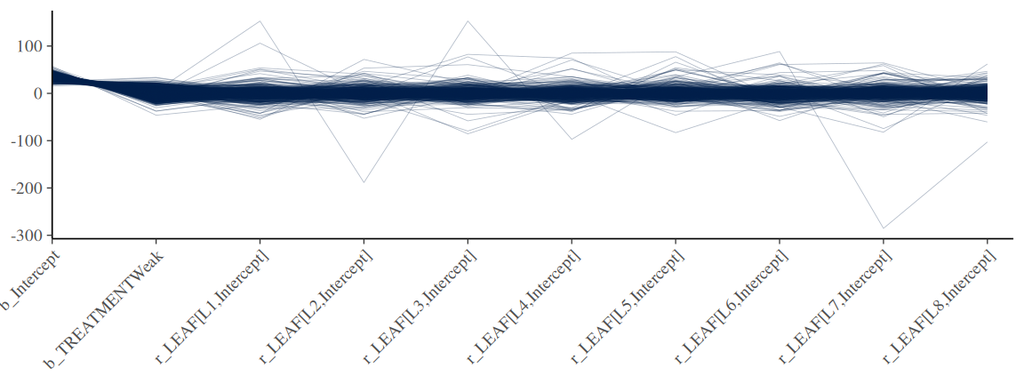

```r
tobacco_brm2 |> mcmc_parcoord(regex_pars = "^b.*|^r.*") +
  theme(axis.text.x = element_text(angle = 45, hjust = 1))
```

Accordingly, these divergent transitions can be addressed by either:

- reviewing the model structure
- adopting tighter priors
- increase the **adaptive delta** from the default of 0.8 to closer to 1. The adaptive delta defines the average acceptance probability that the sampler should aspire to during the warmup phase. Increasing the adaptive delta results in a smaller step size (and thus fewer divergences and more robust samples) however it will also result in slower sampling speeds.

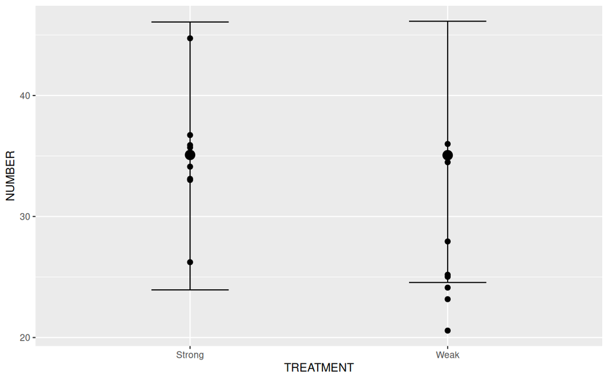

```r
tobacco_brm2 |>
  conditional_effects() |>
  plot(points = TRUE)
```

```
Note: uncertainty of error terms are not taken into account. Consider
  setting `interval` to "prediction". This will call `posterior_predict()`
  instead of `posterior_epred()`.
```

```
Data points may overlap. Use the `jitter` argument to add some amount of
  random variation to the location of data points and avoid overplotting.
```

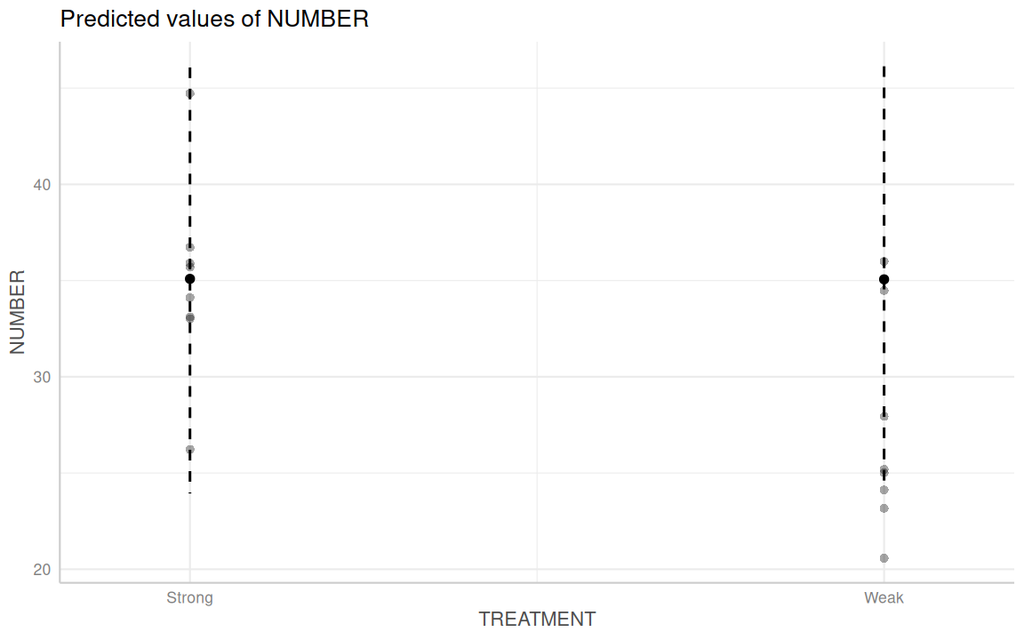

```r
tobacco_brm2 |>
  ggpredict() |>
  plot(show_data = TRUE)
```

```r
tobacco_brm3 <- update(tobacco_brm2,
  sample_prior = "yes",
  control = list(adapt_delta = 0.99, max_treedepth = 20),
  refresh = 0, cores = 3
)
```

```
The desired updates require recompiling the model
```

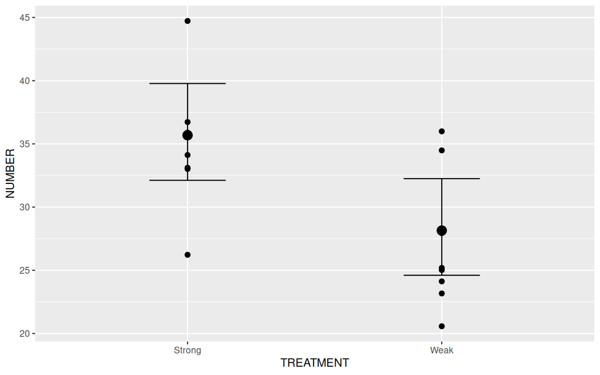

```r
tobacco_brm3 |>
  conditional_effects() |>
  plot(points = TRUE)
```

```
Note: uncertainty of error terms are not taken into account. Consider
  setting `interval` to "prediction". This will call `posterior_predict()`
  instead of `posterior_epred()`.
```

```
Data points may overlap. Use the `jitter` argument to add some amount of
  random variation to the location of data points and avoid overplotting.
```

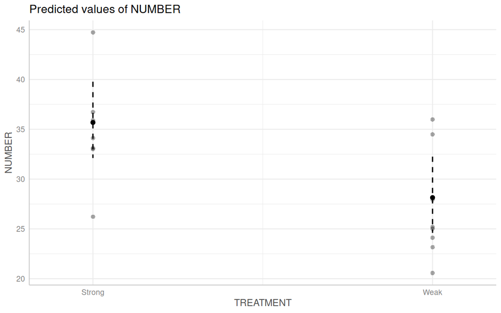

```r
tobacco_brm3 |>
  ggpredict() |>
  plot(show_data = TRUE)
```

**Plotting prior and posterior**

```r
tobacco_brm3 |> get_variables()
```

```
 [1] "b_Intercept"          "b_TREATMENTWeak"      "sd_LEAF__Intercept"
 [4] "sigma"                "Intercept"            "r_LEAF[L1,Intercept]"
 [7] "r_LEAF[L2,Intercept]" "r_LEAF[L3,Intercept]" "r_LEAF[L4,Intercept]"
[10] "r_LEAF[L5,Intercept]" "r_LEAF[L6,Intercept]" "r_LEAF[L7,Intercept]"
[13] "r_LEAF[L8,Intercept]" "prior_Intercept"      "prior_b"
[16] "prior_sigma"          "prior_sd_LEAF"        "lprior"
[19] "lp__"                 "accept_stat__"        "stepsize__"
[22] "treedepth__"          "n_leapfrog__"         "divergent__"
[25] "energy__"
```

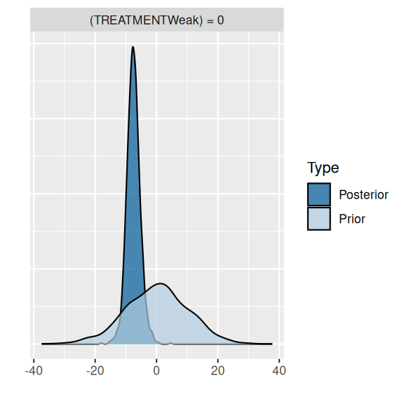

```r
tobacco_brm3 |>
  hypothesis("TREATMENTWeak=0") |>
  plot()
```

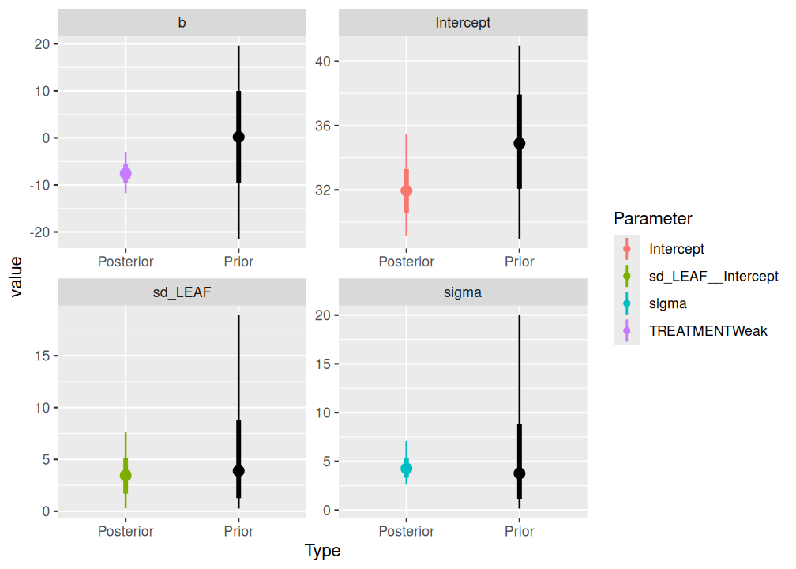

```r
tobacco_brm3 |> SUYR_prior_and_posterior()
```

**Random intercept/slope model**

While we are here, we might like to explore a random intercept/slope model

```r
priors <- prior(normal(35, 3), class = "Intercept") +
  prior(normal(0, 10), class = "b") +
  prior(student_t(3, 0, 5), class = "sigma") +
  prior(student_t(3, 0, 5), class = "sd") +
  prior(lkj_corr_cholesky(1), class = "cor")
tobacco_form <- bf(NUMBER ~ (TREATMENT | LEAF) + TREATMENT,
  family = gaussian()
)

tobacco_brm4 <- brm(tobacco_form,
  data = tobacco,
  prior = priors,
  sample_prior = "yes",
  iter = 5000,
  warmup = 1000,
  chains = 3,
  thin = 5,
  refresh = 0,
  control = list(adapt_delta = 0.99),
  backend = "rstan"
)
```

```r
tobacco_brm4 |> get_variables()
```

```
 [1] "b_Intercept"                        "b_TREATMENTWeak"
 [3] "sd_LEAF__Intercept"                 "sd_LEAF__TREATMENTWeak"
 [5] "cor_LEAF__Intercept__TREATMENTWeak" "sigma"
 [7] "Intercept"                          "r_LEAF[L1,Intercept]"
 [9] "r_LEAF[L2,Intercept]"               "r_LEAF[L3,Intercept]"
[11] "r_LEAF[L4,Intercept]"               "r_LEAF[L5,Intercept]"
[13] "r_LEAF[L6,Intercept]"               "r_LEAF[L7,Intercept]"
[15] "r_LEAF[L8,Intercept]"               "r_LEAF[L1,TREATMENTWeak]"
[17] "r_LEAF[L2,TREATMENTWeak]"           "r_LEAF[L3,TREATMENTWeak]"
[19] "r_LEAF[L4,TREATMENTWeak]"           "r_LEAF[L5,TREATMENTWeak]"
[21] "r_LEAF[L6,TREATMENTWeak]"           "r_LEAF[L7,TREATMENTWeak]"
[23] "r_LEAF[L8,TREATMENTWeak]"           "prior_Intercept"
[25] "prior_b"                            "prior_sigma"
[27] "prior_sd_LEAF"                      "prior_cor_LEAF"
[29] "lprior"                             "lp__"
[31] "accept_stat__"                      "stepsize__"
[33] "treedepth__"                        "n_leapfrog__"
[35] "divergent__"                        "energy__"
```

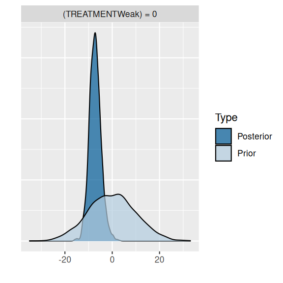

```r
tobacco_brm4 |>
  hypothesis("TREATMENTWeak=0") |>
  plot()
```

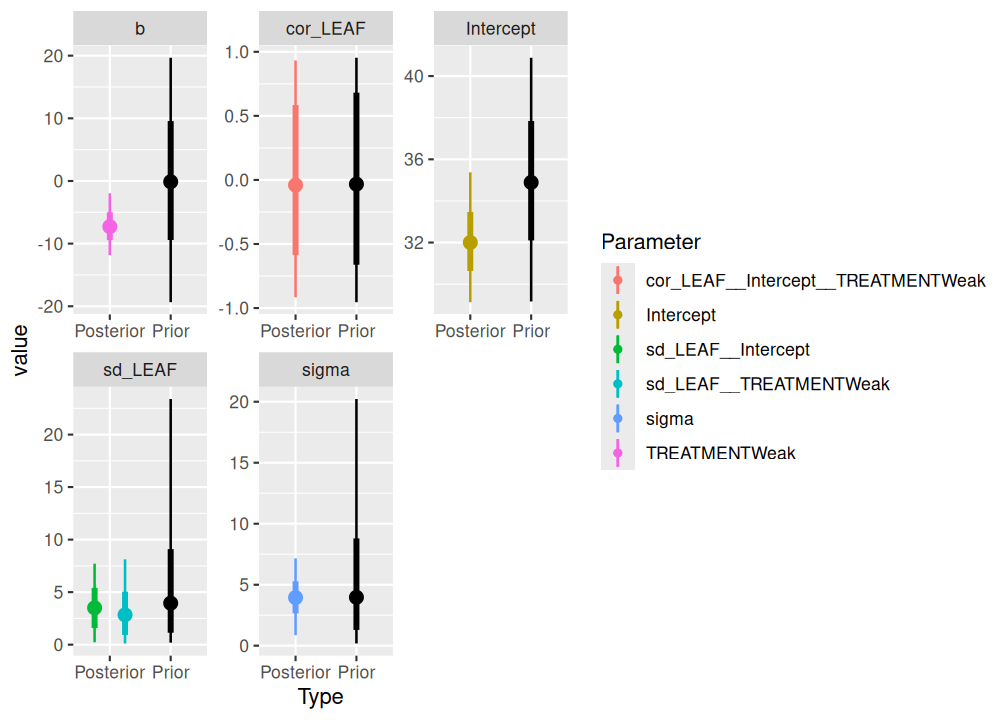

```r
tobacco_brm4 |> SUYR_prior_and_posterior()
```

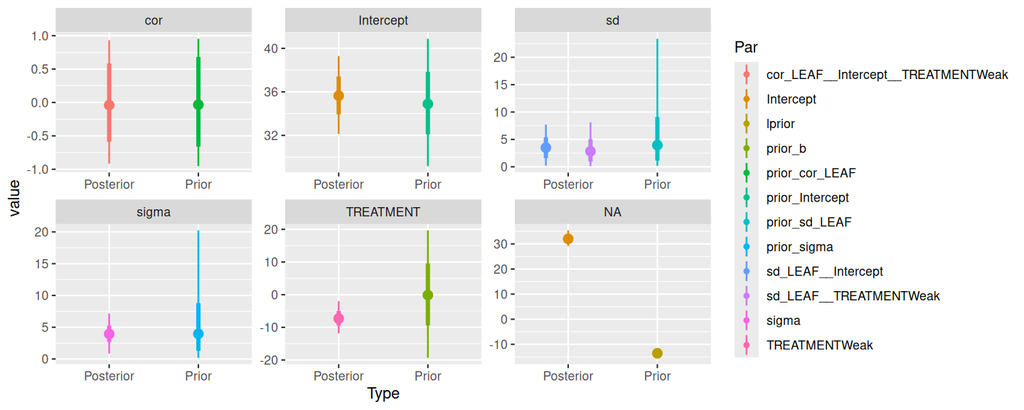

```r
tobacco_brm4 |>
  posterior_samples() |>
  dplyr::select(-`lp__`) |>
  pivot_longer(everything(), names_to = "key") |>
  filter(!str_detect(key, "^r")) |>
  mutate(
    Type = ifelse(str_detect(key, "prior"), "Prior", "Posterior"),
    ## Class = ifelse(str_detect(key, 'Intercept'),  'Intercept',
    ##         ifelse(str_detect(key, 'b'),  'b', 'sigma')),
    Class = case_when(
      str_detect(key, "(^b|^prior).*Intercept$") ~ "Intercept",
      str_detect(key, "b_TREATMENT|prior_b") ~ "TREATMENT",
      str_detect(key, "sd") ~ "sd",
      str_detect(key, "^cor|prior_cor") ~ "cor",
      str_detect(key, "sigma") ~ "sigma"
    ),
    Par = str_replace(key, "b_", "")
  ) |>
  ggplot(aes(x = Type, y = value, color = Par)) +
  stat_pointinterval(position = position_dodge()) +
  facet_wrap(~Class, scales = "free")
```

**Compare models**

We can compare the two models using LOO

```r
(l.1 <- tobacco_brm3 |> loo())
```

```
Computed from 1500 by 16 log-likelihood matrix.

         Estimate  SE
elpd_loo    -50.2 2.5
p_loo         6.6 1.4
looic       100.4 5.1
------
MCSE of elpd_loo is NA.
MCSE and ESS estimates assume MCMC draws (r_eff in [0.7, 1.0]).

Pareto k diagnostic values:
                          Count Pct.    Min. ESS
(-Inf, 0.69]   (good)     9     56.2%   325
   (0.69, 1]   (bad)      7     43.8%   <NA>
    (1, Inf)   (very bad) 0      0.0%   <NA>
See help('pareto-k-diagnostic') for details.
```

```r
(l.2 <- tobacco_brm4 |> loo())
```

```
Computed from 2400 by 16 log-likelihood matrix.

         Estimate  SE
elpd_loo    -49.1 2.5
p_loo        10.0 1.8
looic        98.3 5.0
------
MCSE of elpd_loo is NA.
MCSE and ESS estimates assume MCMC draws (r_eff in [0.0, 0.1]).

Pareto k diagnostic values:
                         Count Pct.    Min. ESS
(-Inf, 0.7]   (good)     13    81.2%   10
   (0.7, 1]   (bad)       3    18.8%   <NA>
   (1, Inf)   (very bad)  0     0.0%   <NA>
See help('pareto-k-diagnostic') for details.
```

```r
loo_compare(l.1, l.2)
```

```
             elpd_diff se_diff
tobacco_brm4  0.0       0.0
tobacco_brm3 -1.1       0.7
```

Whilst the random intercept/slope has a slightly smaller looic, when we consider the standard error (or rather an interval of +- 2.5xSE), there is no support for this more complex model over the simpler random intercept only model. Consequently, we will continue with the random intercept model.

# 6 MCMC sampling diagnostics

**brms**

**bayesplot**

The `bayesplot` package offers a range of MCMC diagnostics as well as Posterior Probability Checks (PPC), all of which have a convenient `plot()` interface. Lets start with the MCMC diagnostics.

**See list of available diagnostics by name**

```r
available_mcmc()
```

```
bayesplot MCMC module:
  mcmc_acf
  mcmc_acf_bar
  mcmc_areas
  mcmc_areas_ridges
  mcmc_combo
  mcmc_dens
  mcmc_dens_chains
  mcmc_dens_overlay
  mcmc_hex
  mcmc_hist
  mcmc_hist_by_chain
  mcmc_intervals
  mcmc_neff
  mcmc_neff_hist
  mcmc_nuts_acceptance
  mcmc_nuts_divergence
  mcmc_nuts_energy
  mcmc_nuts_stepsize
  mcmc_nuts_treedepth
  mcmc_pairs
  mcmc_parcoord
  mcmc_rank_ecdf
  mcmc_rank_hist
  mcmc_rank_overlay
  mcmc_recover_hist
  mcmc_recover_intervals
  mcmc_recover_scatter
  mcmc_rhat
  mcmc_rhat_hist
  mcmc_scatter
  mcmc_trace
  mcmc_trace_highlight
  mcmc_violin
```

Of these, we will focus on:

- trace: this plots the estimates of each parameter over the post-warmup length of each MCMC chain. Each chain is plotted in a different shade of blue, with each parameter in its own facet. Ideally, each **trace** should just look like noise without any discernible drift and each of the traces for a specific parameter should look the same (i.e, should not be displaced above or below any other trace for that parameter).

```
No divergences to plot.
```

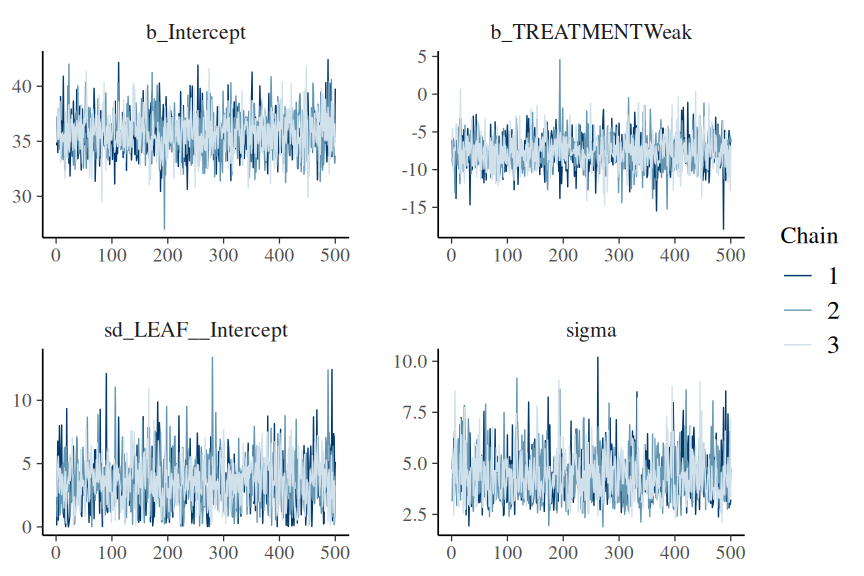

```r
tobacco_brm3 |> mcmc_plot(type = "trace")
```

The chains appear well mixed and very similar

- acf_bar (autocorrelation function): plots the autocorrelation between successive MCMC sample lags for each parameter and each chain

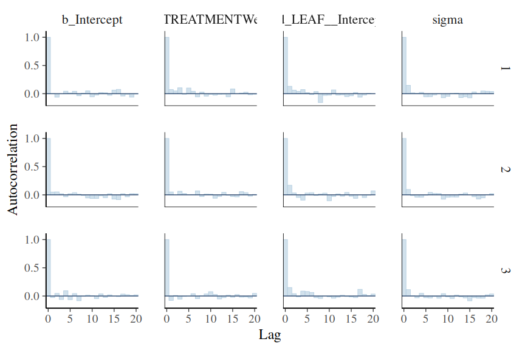

```r
tobacco_brm3 |> mcmc_plot(type = "acf_bar")
```

There is no evidence of autocorrelation in the MCMC samples

- rhat_hist: Rhat is a **scale reduction factor** measure of convergence between the chains. The closer the values are to 1, the more the chains have converged. Values greater than 1.05 indicate a lack of convergence. There will be an Rhat value for each parameter estimated.

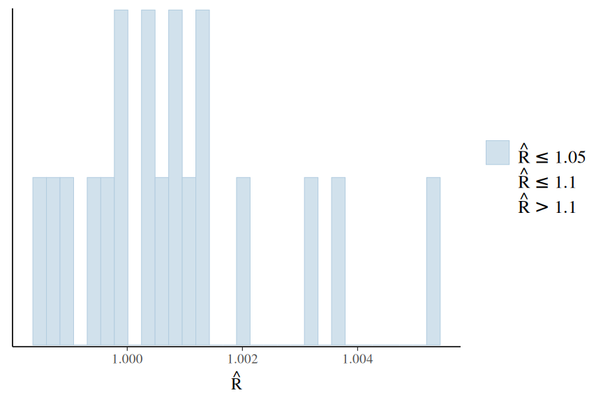

```r
tobacco_brm3 |> mcmc_plot(type = "rhat_hist")
```

All Rhat values are below 1.05, suggesting the chains have converged.

- neff_hist (number of effective samples): the ratio of the number of effective samples (those not rejected by the sampler) to the number of samples provides an indication of the effectiveness (and efficiency) of the MCMC sampler. Ratios that are less than 0.5 for a parameter suggest that the sampler spent considerable time in difficult areas of the sampling domain and rejected more than half of the samples (replacing them with the previous effective sample).